# Versal RF Data Converter

# Versal RF Data Converter

The Versal RF Data Converter block simulates the hardened Data Converter IP block from Versal RF devices.

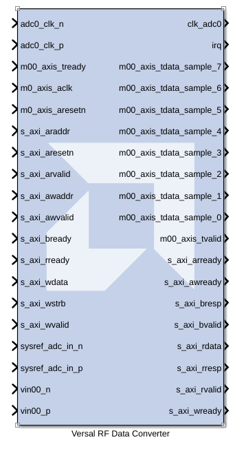

**This block is provided as Early Access functionality in 2026.1 for the purpose of gathering customer feedback. For more information, refer to the [Versal RF Series Tools Early Access Secure Site](https://account.amd.com/en/member/versal-rf-tools-ea.html).**

## Parameters

#### Enable Multi Tile Sync

Dialog parameter.

#### Band

Dialog parameter.

#### Link Coupling

Dialog parameter.

#### Enable ADC

Dialog parameter.

#### Invert Q Output

Dialog parameter.

#### Dither

Dialog parameter.

#### Latency Mode

Dialog parameter.

#### Enable TDD Real Time Ports

Dialog parameter.

#### Datapath Mode

Dialog parameter.

#### Digital Output Data

Dialog parameter.

#### Decimation Mode

Dialog parameter.

#### Samples per AXI4-Stream Cycle

Dialog parameter.

#### Enable ADC Observation Channel Ports

Dialog parameter.

#### Decimation Mode

Dialog parameter.

#### Samples per AXI4-Stream Cycle

Dialog parameter.

#### First Stage DDC Decimation

Dialog parameter.

#### Frequency

Dialog parameter.

#### Mixer Type

Dialog parameter.

#### Mixer Mode

Dialog parameter.

#### NCO Frequency DDC0 (GHz)

Dialog parameter.

#### NCO Phase

Dialog parameter.

#### NCO Frequency DDC1 (GHz)

Dialog parameter.

#### NCO Phase NC01

Dialog parameter.

#### Nyquist Zone

Dialog parameter.

#### Calibration Mode

Dialog parameter.

#### Enable ADC

Dialog parameter.

#### Invert Q Output

Dialog parameter.

#### Dither

Dialog parameter.

#### Latency Mode

Dialog parameter.

#### Enable TDD Real Time Ports

Dialog parameter.

#### Datapath Mode

Dialog parameter.

#### Digital Output Data

Dialog parameter.

#### Decimation Mode

Dialog parameter.

#### Samples per AXI4-Stream Cycle

Dialog parameter.

#### Enable ADC Observation Channel Ports

Dialog parameter.

#### Decimation Mode

Dialog parameter.

#### Samples per AXI4-Stream Cycle

Dialog parameter.

#### First Stage DDC Decimation

Dialog parameter.

#### Frequency

Dialog parameter.

#### Mixer Type

Dialog parameter.

#### Mixer Mode

Dialog parameter.

#### NCO Frequency DDC0 (GHz)

Dialog parameter.

#### NCO Phase

Dialog parameter.

#### NCO Frequency DDC1 (GHz)

Dialog parameter.

#### NCO Phase NC01

Dialog parameter.

#### Nyquist Zone

Dialog parameter.

#### Calibration Mode

Dialog parameter.

#### Enable ADC

Dialog parameter.

#### Invert Q Output

Dialog parameter.

#### Dither

Dialog parameter.

#### Latency Mode

Dialog parameter.

#### Enable TDD Real Time Ports

Dialog parameter.

#### Datapath Mode

Dialog parameter.

#### Digital Output Data

Dialog parameter.

#### Decimation Mode

Dialog parameter.

#### Samples per AXI4-Stream Cycle

Dialog parameter.

#### Enable ADC Observation Channel Ports

Dialog parameter.

#### Decimation Mode

Dialog parameter.

#### Samples per AXI4-Stream Cycle

Dialog parameter.

#### First Stage DDC Decimation

Dialog parameter.

#### Frequency

Dialog parameter.

#### Mixer Type

Dialog parameter.

#### Mixer Mode

Dialog parameter.

#### NCO Frequency DDC0 (GHz)

Dialog parameter.

#### NCO Phase

Dialog parameter.

#### NCO Frequency DDC1 (GHz)

Dialog parameter.

#### NCO Phase NC01

Dialog parameter.

#### Nyquist Zone

Dialog parameter.

#### Calibration Mode

Dialog parameter.

#### Enable ADC

Dialog parameter.

#### Invert Q Output

Dialog parameter.

#### Dither

Dialog parameter.

#### Latency Mode

Dialog parameter.

#### Enable TDD Real Time Ports

Dialog parameter.

#### Datapath Mode

Dialog parameter.

#### Digital Output Data

Dialog parameter.

#### Decimation Mode

Dialog parameter.

#### Samples per AXI4-Stream Cycle

Dialog parameter.

#### Enable ADC Observation Channel Ports

Dialog parameter.

#### Decimation Mode

Dialog parameter.

#### Samples per AXI4-Stream Cycle

Dialog parameter.

#### First Stage DDC Decimation

Dialog parameter.

#### Frequency

Dialog parameter.

#### Mixer Type

Dialog parameter.

#### Mixer Mode

Dialog parameter.

#### NCO Frequency DDC0 (GHz)

Dialog parameter.

#### NCO Phase

Dialog parameter.

#### NCO Frequency DDC1 (GHz)

Dialog parameter.

#### NCO Phase NC01

Dialog parameter.

#### Nyquist Zone

Dialog parameter.

#### Calibration Mode

Dialog parameter.

#### Enable Multi Tile Sync

Dialog parameter.

#### Band

Dialog parameter.

#### Link Coupling

Dialog parameter.

#### Enable ADC

Dialog parameter.

#### Invert Q Output

Dialog parameter.

#### Dither

Dialog parameter.

#### Latency Mode

Dialog parameter.

#### Enable TDD Real Time Ports

Dialog parameter.

#### Datapath Mode

Dialog parameter.

#### Digital Output Data

Dialog parameter.

#### Decimation Mode

Dialog parameter.

#### Samples per AXI4-Stream Cycle

Dialog parameter.

#### Enable ADC Observation Channel Ports

Dialog parameter.

#### Decimation Mode

Dialog parameter.

#### Samples per AXI4-Stream Cycle

Dialog parameter.

#### First Stage DDC Decimation

Dialog parameter.

#### Frequency

Dialog parameter.

#### Mixer Type

Dialog parameter.

#### Mixer Mode

Dialog parameter.

#### NCO Frequency DDC0 (GHz)

Dialog parameter.

#### NCO Phase

Dialog parameter.

#### NCO Frequency DDC1 (GHz)

Dialog parameter.

#### NCO Phase NC01

Dialog parameter.

#### Nyquist Zone

Dialog parameter.

#### Calibration Mode

Dialog parameter.

#### Enable ADC

Dialog parameter.

#### Invert Q Output

Dialog parameter.

#### Dither

Dialog parameter.

#### Latency Mode

Dialog parameter.

#### Enable TDD Real Time Ports

Dialog parameter.

#### Datapath Mode

Dialog parameter.

#### Digital Output Data

Dialog parameter.

#### Decimation Mode

Dialog parameter.

#### Samples per AXI4-Stream Cycle

Dialog parameter.

#### Enable ADC Observation Channel Ports

Dialog parameter.

#### Decimation Mode

Dialog parameter.

#### Samples per AXI4-Stream Cycle

Dialog parameter.

#### First Stage DDC Decimation

Dialog parameter.

#### Frequency

Dialog parameter.

#### Mixer Type

Dialog parameter.

#### Mixer Mode

Dialog parameter.

#### NCO Frequency DDC0 (GHz)

Dialog parameter.

#### NCO Phase

Dialog parameter.

#### NCO Frequency DDC1 (GHz)

Dialog parameter.

#### NCO Phase NC01

Dialog parameter.

#### Nyquist Zone

Dialog parameter.

#### Calibration Mode

Dialog parameter.

#### Enable ADC

Dialog parameter.

#### Invert Q Output

Dialog parameter.

#### Dither

Dialog parameter.

#### Latency Mode

Dialog parameter.

#### Enable TDD Real Time Ports

Dialog parameter.

#### Datapath Mode

Dialog parameter.

#### Digital Output Data

Dialog parameter.

#### Decimation Mode

Dialog parameter.

#### Samples per AXI4-Stream Cycle

Dialog parameter.

#### Enable ADC Observation Channel Ports

Dialog parameter.

#### Decimation Mode

Dialog parameter.

#### Samples per AXI4-Stream Cycle

Dialog parameter.

#### First Stage DDC Decimation

Dialog parameter.

#### Frequency

Dialog parameter.

#### Mixer Type

Dialog parameter.

#### Mixer Mode

Dialog parameter.

#### NCO Frequency DDC0 (GHz)

Dialog parameter.

#### NCO Phase

Dialog parameter.

#### NCO Frequency DDC1 (GHz)

Dialog parameter.

#### NCO Phase NC01

Dialog parameter.

#### Nyquist Zone

Dialog parameter.

#### Calibration Mode

Dialog parameter.

#### Enable ADC

Dialog parameter.

#### Invert Q Output

Dialog parameter.

#### Dither

Dialog parameter.

#### Latency Mode

Dialog parameter.

#### Enable TDD Real Time Ports

Dialog parameter.

#### Datapath Mode

Dialog parameter.

#### Digital Output Data

Dialog parameter.

#### Decimation Mode

Dialog parameter.

#### Samples per AXI4-Stream Cycle

Dialog parameter.

#### Enable ADC Observation Channel Ports

Dialog parameter.

#### Decimation Mode

Dialog parameter.

#### Samples per AXI4-Stream Cycle

Dialog parameter.

#### First Stage DDC Decimation

Dialog parameter.

#### Frequency

Dialog parameter.

#### Mixer Type

Dialog parameter.

#### Mixer Mode

Dialog parameter.

#### NCO Frequency DDC0 (GHz)

Dialog parameter.

#### NCO Phase

Dialog parameter.

#### NCO Frequency DDC1 (GHz)

Dialog parameter.

#### NCO Phase NC01

Dialog parameter.

#### Nyquist Zone

Dialog parameter.

#### Calibration Mode

Dialog parameter.

#### Enable Multi Tile Sync

Dialog parameter.

#### Band

Dialog parameter.

#### Link Coupling

Dialog parameter.

#### Enable ADC

Dialog parameter.

#### Invert Q Output

Dialog parameter.

#### Dither

Dialog parameter.

#### Latency Mode

Dialog parameter.

#### Enable TDD Real Time Ports

Dialog parameter.

#### Datapath Mode

Dialog parameter.

#### Digital Output Data

Dialog parameter.

#### Decimation Mode

Dialog parameter.

#### Samples per AXI4-Stream Cycle

Dialog parameter.

#### Enable ADC Observation Channel Ports

Dialog parameter.

#### Decimation Mode

Dialog parameter.

#### Samples per AXI4-Stream Cycle

Dialog parameter.

#### First Stage DDC Decimation

Dialog parameter.

#### Frequency

Dialog parameter.

#### Mixer Type

Dialog parameter.

#### Mixer Mode

Dialog parameter.

#### NCO Frequency DDC0 (GHz)

Dialog parameter.

#### NCO Phase

Dialog parameter.

#### NCO Frequency DDC1 (GHz)

Dialog parameter.

#### NCO Phase NC01

Dialog parameter.

#### Nyquist Zone

Dialog parameter.

#### Calibration Mode

Dialog parameter.

#### Enable ADC

Dialog parameter.

#### Invert Q Output

Dialog parameter.

#### Dither

Dialog parameter.

#### Latency Mode

Dialog parameter.

#### Enable TDD Real Time Ports

Dialog parameter.

#### Datapath Mode

Dialog parameter.

#### Digital Output Data

Dialog parameter.

#### Decimation Mode

Dialog parameter.

#### Samples per AXI4-Stream Cycle

Dialog parameter.

#### Enable ADC Observation Channel Ports

Dialog parameter.

#### Decimation Mode

Dialog parameter.

#### Samples per AXI4-Stream Cycle

Dialog parameter.

#### First Stage DDC Decimation

Dialog parameter.

#### Frequency

Dialog parameter.

#### Mixer Type

Dialog parameter.

#### Mixer Mode

Dialog parameter.

#### NCO Frequency DDC0 (GHz)

Dialog parameter.

#### NCO Phase

Dialog parameter.

#### NCO Frequency DDC1 (GHz)

Dialog parameter.

#### NCO Phase NC01

Dialog parameter.

#### Nyquist Zone

Dialog parameter.

#### Calibration Mode

Dialog parameter.

#### Enable ADC

Dialog parameter.

#### Invert Q Output

Dialog parameter.

#### Dither

Dialog parameter.

#### Latency Mode

Dialog parameter.

#### Enable TDD Real Time Ports

Dialog parameter.

#### Datapath Mode

Dialog parameter.

#### Digital Output Data

Dialog parameter.

#### Decimation Mode

Dialog parameter.

#### Samples per AXI4-Stream Cycle

Dialog parameter.

#### Enable ADC Observation Channel Ports

Dialog parameter.

#### Decimation Mode

Dialog parameter.

#### Samples per AXI4-Stream Cycle

Dialog parameter.

#### First Stage DDC Decimation

Dialog parameter.

#### Frequency

Dialog parameter.

#### Mixer Type

Dialog parameter.

#### Mixer Mode

Dialog parameter.

#### NCO Frequency DDC0 (GHz)

Dialog parameter.

#### NCO Phase

Dialog parameter.

#### NCO Frequency DDC1 (GHz)

Dialog parameter.

#### NCO Phase NC01

Dialog parameter.

#### Nyquist Zone

Dialog parameter.

#### Calibration Mode

Dialog parameter.

#### Enable ADC

Dialog parameter.

#### Invert Q Output

Dialog parameter.

#### Dither

Dialog parameter.

#### Latency Mode

Dialog parameter.

#### Enable TDD Real Time Ports

Dialog parameter.

#### Datapath Mode

Dialog parameter.

#### Digital Output Data

Dialog parameter.

#### Decimation Mode

Dialog parameter.

#### Samples per AXI4-Stream Cycle

Dialog parameter.

#### Enable ADC Observation Channel Ports

Dialog parameter.

#### Decimation Mode

Dialog parameter.

#### Samples per AXI4-Stream Cycle

Dialog parameter.

#### First Stage DDC Decimation

Dialog parameter.

#### Frequency

Dialog parameter.

#### Mixer Type

Dialog parameter.

#### Mixer Mode

Dialog parameter.

#### NCO Frequency DDC0 (GHz)

Dialog parameter.

#### NCO Phase

Dialog parameter.

#### NCO Frequency DDC1 (GHz)

Dialog parameter.

#### NCO Phase NC01

Dialog parameter.

#### Nyquist Zone

Dialog parameter.

#### Calibration Mode

Dialog parameter.

#### Enable Multi Tile Sync

Dialog parameter.

#### Band

Dialog parameter.

#### Link Coupling

Dialog parameter.

#### Enable ADC

Dialog parameter.

#### Invert Q Output

Dialog parameter.

#### Dither

Dialog parameter.

#### Latency Mode

Dialog parameter.

#### Enable TDD Real Time Ports

Dialog parameter.

#### Datapath Mode

Dialog parameter.

#### Digital Output Data

Dialog parameter.

#### Decimation Mode

Dialog parameter.

#### Samples per AXI4-Stream Cycle

Dialog parameter.

#### Enable ADC Observation Channel Ports

Dialog parameter.

#### Decimation Mode

Dialog parameter.

#### Samples per AXI4-Stream Cycle

Dialog parameter.

#### First Stage DDC Decimation

Dialog parameter.

#### Frequency

Dialog parameter.

#### Mixer Type

Dialog parameter.

#### Mixer Mode

Dialog parameter.

#### NCO Frequency DDC0 (GHz)

Dialog parameter.

#### NCO Phase

Dialog parameter.

#### NCO Frequency DDC1 (GHz)

Dialog parameter.

#### NCO Phase NC01

Dialog parameter.

#### Nyquist Zone

Dialog parameter.

#### Calibration Mode

Dialog parameter.

#### Enable ADC

Dialog parameter.

#### Invert Q Output

Dialog parameter.

#### Dither

Dialog parameter.

#### Latency Mode

Dialog parameter.

#### Enable TDD Real Time Ports

Dialog parameter.

#### Datapath Mode

Dialog parameter.

#### Digital Output Data

Dialog parameter.

#### Decimation Mode

Dialog parameter.

#### Samples per AXI4-Stream Cycle

Dialog parameter.

#### Enable ADC Observation Channel Ports

Dialog parameter.

#### Decimation Mode

Dialog parameter.

#### Samples per AXI4-Stream Cycle

Dialog parameter.

#### First Stage DDC Decimation

Dialog parameter.

#### Frequency

Dialog parameter.

#### Mixer Type

Dialog parameter.

#### Mixer Mode

Dialog parameter.

#### NCO Frequency DDC0 (GHz)

Dialog parameter.

#### NCO Phase

Dialog parameter.

#### NCO Frequency DDC1 (GHz)

Dialog parameter.

#### NCO Phase NC01

Dialog parameter.

#### Nyquist Zone

Dialog parameter.

#### Calibration Mode

Dialog parameter.

#### Enable ADC

Dialog parameter.

#### Invert Q Output

Dialog parameter.

#### Dither

Dialog parameter.

#### Latency Mode

Dialog parameter.

#### Enable TDD Real Time Ports

Dialog parameter.

#### Datapath Mode

Dialog parameter.

#### Digital Output Data

Dialog parameter.

#### Decimation Mode

Dialog parameter.

#### Samples per AXI4-Stream Cycle

Dialog parameter.

#### Enable ADC Observation Channel Ports

Dialog parameter.

#### Decimation Mode

Dialog parameter.

#### Samples per AXI4-Stream Cycle

Dialog parameter.

#### First Stage DDC Decimation

Dialog parameter.

#### Frequency

Dialog parameter.

#### Mixer Type

Dialog parameter.

#### Mixer Mode

Dialog parameter.

#### NCO Frequency DDC0 (GHz)

Dialog parameter.

#### NCO Phase

Dialog parameter.

#### NCO Frequency DDC1 (GHz)

Dialog parameter.

#### NCO Phase NC01

Dialog parameter.

#### Nyquist Zone

Dialog parameter.

#### Calibration Mode

Dialog parameter.

#### Enable ADC

Dialog parameter.

#### Invert Q Output

Dialog parameter.

#### Dither

Dialog parameter.

#### Latency Mode

Dialog parameter.

#### Enable TDD Real Time Ports

Dialog parameter.

#### Datapath Mode

Dialog parameter.

#### Digital Output Data

Dialog parameter.

#### Decimation Mode

Dialog parameter.

#### Samples per AXI4-Stream Cycle

Dialog parameter.

#### Enable ADC Observation Channel Ports

Dialog parameter.

#### Decimation Mode

Dialog parameter.

#### Samples per AXI4-Stream Cycle

Dialog parameter.

#### First Stage DDC Decimation

Dialog parameter.

#### Frequency

Dialog parameter.

#### Mixer Type

Dialog parameter.

#### Mixer Mode

Dialog parameter.

#### NCO Frequency DDC0 (GHz)

Dialog parameter.

#### NCO Phase

Dialog parameter.

#### NCO Frequency DDC1 (GHz)

Dialog parameter.

#### NCO Phase NC01

Dialog parameter.

#### Nyquist Zone

Dialog parameter.

#### Calibration Mode

Dialog parameter.

#### Enable Multi Tile Sync

Dialog parameter.

#### Link Coupling

Dialog parameter.

#### Band

Dialog parameter.

#### Output Power

Dialog parameter.

#### Enable DAC

Dialog parameter.

#### Invert Q Output

Dialog parameter.

#### Inverse Sinc Filter

Dialog parameter.

#### Latency Mode

Dialog parameter.

#### Enable TDD Real Time Ports

Dialog parameter.

#### Datapath Mode

Dialog parameter.

#### Analog Output Data

Dialog parameter.

#### Interpolation Mode

Dialog parameter.

#### Samples per AXI4-Stream Cycle

Dialog parameter.

#### Mixer Type

Dialog parameter.

#### Mixer Mode

Dialog parameter.

#### NCO Frequency DUC0 (GHz)

Dialog parameter.

#### NCO Phase

Dialog parameter.

#### NCO Frequency DUC1 (GHz)

Dialog parameter.

#### NCO Phase NC01

Dialog parameter.

#### Second Stage DUC Interpolation

Dialog parameter.

#### Frequency

Dialog parameter.

#### Nyquist Zone

Dialog parameter.

#### Decoder Mode

Dialog parameter.

#### Enable DAC

Dialog parameter.

#### Invert Q Output

Dialog parameter.

#### Inverse Sinc Filter

Dialog parameter.

#### Latency Mode

Dialog parameter.

#### Enable TDD Real Time Ports

Dialog parameter.

#### Datapath Mode

Dialog parameter.

#### Analog Output Data

Dialog parameter.

#### Interpolation Mode

Dialog parameter.

#### Samples per AXI4-Stream Cycle

Dialog parameter.

#### Mixer Type

Dialog parameter.

#### Mixer Mode

Dialog parameter.

#### NCO Frequency DUC0 (GHz)

Dialog parameter.

#### NCO Phase

Dialog parameter.

#### NCO Frequency DUC1 (GHz)

Dialog parameter.

#### NCO Phase NC01

Dialog parameter.

#### Second Stage DUC Interpolation

Dialog parameter.

#### Frequency

Dialog parameter.

#### Nyquist Zone

Dialog parameter.

#### Decoder Mode

Dialog parameter.

#### Enable DAC

Dialog parameter.

#### Invert Q Output

Dialog parameter.

#### Inverse Sinc Filter

Dialog parameter.

#### Latency Mode

Dialog parameter.

#### Enable TDD Real Time Ports

Dialog parameter.

#### Datapath Mode

Dialog parameter.

#### Analog Output Data

Dialog parameter.

#### Interpolation Mode

Dialog parameter.

#### Samples per AXI4-Stream Cycle

Dialog parameter.

#### Mixer Type

Dialog parameter.

#### Mixer Mode

Dialog parameter.

#### NCO Frequency DUC0 (GHz)

Dialog parameter.

#### NCO Phase

Dialog parameter.

#### NCO Frequency DUC1 (GHz)

Dialog parameter.

#### NCO Phase NC01

Dialog parameter.

#### Second Stage DUC Interpolation

Dialog parameter.

#### Frequency

Dialog parameter.

#### Nyquist Zone

Dialog parameter.

#### Decoder Mode

Dialog parameter.

#### Enable DAC

Dialog parameter.

#### Invert Q Output

Dialog parameter.

#### Inverse Sinc Filter

Dialog parameter.

#### Latency Mode

Dialog parameter.

#### Enable TDD Real Time Ports

Dialog parameter.

#### Datapath Mode

Dialog parameter.

#### Analog Output Data

Dialog parameter.

#### Interpolation Mode

Dialog parameter.

#### Samples per AXI4-Stream Cycle

Dialog parameter.

#### Mixer Type

Dialog parameter.

#### Mixer Mode

Dialog parameter.

#### NCO Frequency DUC0 (GHz)

Dialog parameter.

#### NCO Phase

Dialog parameter.

#### NCO Frequency DUC1 (GHz)

Dialog parameter.

#### NCO Phase NC01

Dialog parameter.

#### Second Stage DUC Interpolation

Dialog parameter.

#### Frequency

Dialog parameter.

#### Nyquist Zone

Dialog parameter.

#### Decoder Mode

Dialog parameter.

#### Enable Multi Tile Sync

Dialog parameter.

#### Link Coupling

Dialog parameter.

#### Band

Dialog parameter.

#### Output Power

Dialog parameter.

#### Enable DAC

Dialog parameter.

#### Invert Q Output

Dialog parameter.

#### Inverse Sinc Filter

Dialog parameter.

#### Latency Mode

Dialog parameter.

#### Enable TDD Real Time Ports

Dialog parameter.

#### Datapath Mode

Dialog parameter.

#### Analog Output Data

Dialog parameter.

#### Interpolation Mode

Dialog parameter.

#### Samples per AXI4-Stream Cycle

Dialog parameter.

#### Mixer Type

Dialog parameter.

#### Mixer Mode

Dialog parameter.

#### NCO Frequency DUC0 (GHz)

Dialog parameter.

#### NCO Phase

Dialog parameter.

#### NCO Frequency DUC1 (GHz)

Dialog parameter.

#### NCO Phase NC01

Dialog parameter.

#### Second Stage DUC Interpolation

Dialog parameter.

#### Frequency

Dialog parameter.

#### Nyquist Zone

Dialog parameter.

#### Decoder Mode

Dialog parameter.

#### Enable DAC

Dialog parameter.

#### Invert Q Output

Dialog parameter.

#### Inverse Sinc Filter

Dialog parameter.

#### Latency Mode

Dialog parameter.

#### Enable TDD Real Time Ports

Dialog parameter.

#### Datapath Mode

Dialog parameter.

#### Analog Output Data

Dialog parameter.

#### Interpolation Mode

Dialog parameter.

#### Samples per AXI4-Stream Cycle

Dialog parameter.

#### Mixer Type

Dialog parameter.

#### Mixer Mode

Dialog parameter.

#### NCO Frequency DUC0 (GHz)

Dialog parameter.

#### NCO Phase

Dialog parameter.

#### NCO Frequency DUC1 (GHz)

Dialog parameter.

#### NCO Phase NC01

Dialog parameter.

#### Second Stage DUC Interpolation

Dialog parameter.

#### Frequency

Dialog parameter.

#### Nyquist Zone

Dialog parameter.

#### Decoder Mode

Dialog parameter.

#### Enable DAC

Dialog parameter.

#### Invert Q Output

Dialog parameter.

#### Inverse Sinc Filter

Dialog parameter.

#### Latency Mode

Dialog parameter.

#### Enable TDD Real Time Ports

Dialog parameter.

#### Datapath Mode

Dialog parameter.

#### Analog Output Data

Dialog parameter.

#### Interpolation Mode

Dialog parameter.

#### Samples per AXI4-Stream Cycle

Dialog parameter.

#### Mixer Type

Dialog parameter.

#### Mixer Mode

Dialog parameter.

#### NCO Frequency DUC0 (GHz)

Dialog parameter.

#### NCO Phase

Dialog parameter.

#### NCO Frequency DUC1 (GHz)

Dialog parameter.

#### NCO Phase NC01

Dialog parameter.

#### Second Stage DUC Interpolation

Dialog parameter.

#### Frequency

Dialog parameter.

#### Nyquist Zone

Dialog parameter.

#### Decoder Mode

Dialog parameter.

#### Enable DAC

Dialog parameter.

#### Invert Q Output

Dialog parameter.

#### Inverse Sinc Filter

Dialog parameter.

#### Latency Mode

Dialog parameter.

#### Enable TDD Real Time Ports

Dialog parameter.

#### Datapath Mode

Dialog parameter.

#### Analog Output Data

Dialog parameter.

#### Interpolation Mode

Dialog parameter.

#### Samples per AXI4-Stream Cycle

Dialog parameter.

#### Mixer Type

Dialog parameter.

#### Mixer Mode

Dialog parameter.

#### NCO Frequency DUC0 (GHz)

Dialog parameter.

#### NCO Phase

Dialog parameter.

#### NCO Frequency DUC1 (GHz)

Dialog parameter.

#### NCO Phase NC01

Dialog parameter.

#### Second Stage DUC Interpolation

Dialog parameter.

#### Frequency

Dialog parameter.

#### Nyquist Zone

Dialog parameter.

#### Decoder Mode

Dialog parameter.

#### Enable Multi Tile Sync

Dialog parameter.

#### Link Coupling

Dialog parameter.

#### Band

Dialog parameter.

#### Output Power

Dialog parameter.

#### Enable DAC

Dialog parameter.

#### Invert Q Output

Dialog parameter.

#### Inverse Sinc Filter

Dialog parameter.

#### Latency Mode

Dialog parameter.

#### Enable TDD Real Time Ports

Dialog parameter.

#### Datapath Mode

Dialog parameter.

#### Analog Output Data

Dialog parameter.

#### Interpolation Mode

Dialog parameter.

#### Samples per AXI4-Stream Cycle

Dialog parameter.

#### Mixer Type

Dialog parameter.

#### Mixer Mode

Dialog parameter.

#### NCO Frequency DUC0 (GHz)

Dialog parameter.

#### NCO Phase

Dialog parameter.

#### NCO Frequency DUC1 (GHz)

Dialog parameter.

#### NCO Phase NC01

Dialog parameter.

#### Second Stage DUC Interpolation

Dialog parameter.

#### Frequency

Dialog parameter.

#### Nyquist Zone

Dialog parameter.

#### Decoder Mode

Dialog parameter.

#### Enable DAC

Dialog parameter.

#### Invert Q Output

Dialog parameter.

#### Inverse Sinc Filter

Dialog parameter.

#### Latency Mode

Dialog parameter.

#### Enable TDD Real Time Ports

Dialog parameter.

#### Datapath Mode

Dialog parameter.

#### Analog Output Data

Dialog parameter.

#### Interpolation Mode

Dialog parameter.

#### Samples per AXI4-Stream Cycle

Dialog parameter.

#### Mixer Type

Dialog parameter.

#### Mixer Mode

Dialog parameter.

#### NCO Frequency DUC0 (GHz)

Dialog parameter.

#### NCO Phase

Dialog parameter.

#### NCO Frequency DUC1 (GHz)

Dialog parameter.

#### NCO Phase NC01

Dialog parameter.

#### Second Stage DUC Interpolation

Dialog parameter.

#### Frequency

Dialog parameter.

#### Nyquist Zone

Dialog parameter.

#### Decoder Mode

Dialog parameter.

#### Enable DAC

Dialog parameter.

#### Invert Q Output

Dialog parameter.

#### Inverse Sinc Filter

Dialog parameter.

#### Latency Mode

Dialog parameter.

#### Enable TDD Real Time Ports

Dialog parameter.

#### Datapath Mode

Dialog parameter.

#### Analog Output Data

Dialog parameter.

#### Interpolation Mode

Dialog parameter.

#### Samples per AXI4-Stream Cycle

Dialog parameter.

#### Mixer Type

Dialog parameter.

#### Mixer Mode

Dialog parameter.

#### NCO Frequency DUC0 (GHz)

Dialog parameter.

#### NCO Phase

Dialog parameter.

#### NCO Frequency DUC1 (GHz)

Dialog parameter.

#### NCO Phase NC01

Dialog parameter.

#### Second Stage DUC Interpolation

Dialog parameter.

#### Frequency

Dialog parameter.

#### Nyquist Zone

Dialog parameter.

#### Decoder Mode

Dialog parameter.

#### Enable DAC

Dialog parameter.

#### Invert Q Output

Dialog parameter.

#### Inverse Sinc Filter

Dialog parameter.

#### Latency Mode

Dialog parameter.

#### Enable TDD Real Time Ports

Dialog parameter.

#### Datapath Mode

Dialog parameter.

#### Analog Output Data

Dialog parameter.

#### Interpolation Mode

Dialog parameter.

#### Samples per AXI4-Stream Cycle

Dialog parameter.

#### Mixer Type

Dialog parameter.

#### Mixer Mode

Dialog parameter.

#### NCO Frequency DUC0 (GHz)

Dialog parameter.

#### NCO Phase

Dialog parameter.

#### NCO Frequency DUC1 (GHz)

Dialog parameter.

#### NCO Phase NC01

Dialog parameter.

#### Second Stage DUC Interpolation

Dialog parameter.

#### Frequency

Dialog parameter.

#### Nyquist Zone

Dialog parameter.

#### Decoder Mode

Dialog parameter.

#### Enable Multi Tile Sync

Dialog parameter.

#### Link Coupling

Dialog parameter.

#### Band

Dialog parameter.

#### Output Power

Dialog parameter.

#### Enable DAC

Dialog parameter.

#### Invert Q Output

Dialog parameter.

#### Inverse Sinc Filter

Dialog parameter.

#### Latency Mode

Dialog parameter.

#### Enable TDD Real Time Ports

Dialog parameter.

#### Datapath Mode

Dialog parameter.

#### Analog Output Data

Dialog parameter.

#### Interpolation Mode

Dialog parameter.

#### Samples per AXI4-Stream Cycle

Dialog parameter.

#### Mixer Type

Dialog parameter.

#### Mixer Mode

Dialog parameter.

#### NCO Frequency DUC0 (GHz)

Dialog parameter.

#### NCO Phase

Dialog parameter.

#### NCO Frequency DUC1 (GHz)

Dialog parameter.

#### NCO Phase NC01

Dialog parameter.

#### Second Stage DUC Interpolation

Dialog parameter.

#### Frequency

Dialog parameter.

#### Nyquist Zone

Dialog parameter.

#### Decoder Mode

Dialog parameter.

#### Enable DAC

Dialog parameter.

#### Invert Q Output

Dialog parameter.

#### Inverse Sinc Filter

Dialog parameter.

#### Latency Mode

Dialog parameter.

#### Enable TDD Real Time Ports

Dialog parameter.

#### Datapath Mode

Dialog parameter.

#### Analog Output Data

Dialog parameter.

#### Interpolation Mode

Dialog parameter.

#### Samples per AXI4-Stream Cycle

Dialog parameter.

#### Mixer Type

Dialog parameter.

#### Mixer Mode

Dialog parameter.

#### NCO Frequency DUC0 (GHz)

Dialog parameter.

#### NCO Phase

Dialog parameter.

#### NCO Frequency DUC1 (GHz)

Dialog parameter.

#### NCO Phase NC01

Dialog parameter.

#### Second Stage DUC Interpolation

Dialog parameter.

#### Frequency

Dialog parameter.

#### Nyquist Zone

Dialog parameter.

#### Decoder Mode

Dialog parameter.

#### Enable DAC

Dialog parameter.

#### Invert Q Output

Dialog parameter.

#### Inverse Sinc Filter

Dialog parameter.

#### Latency Mode

Dialog parameter.

#### Enable TDD Real Time Ports

Dialog parameter.

#### Datapath Mode

Dialog parameter.

#### Analog Output Data

Dialog parameter.

#### Interpolation Mode

Dialog parameter.

#### Samples per AXI4-Stream Cycle

Dialog parameter.

#### Mixer Type

Dialog parameter.

#### Mixer Mode

Dialog parameter.

#### NCO Frequency DUC0 (GHz)

Dialog parameter.

#### NCO Phase

Dialog parameter.

#### NCO Frequency DUC1 (GHz)

Dialog parameter.

#### NCO Phase NC01

Dialog parameter.

#### Second Stage DUC Interpolation

Dialog parameter.

#### Frequency

Dialog parameter.

#### Nyquist Zone

Dialog parameter.

#### Decoder Mode

Dialog parameter.

#### Enable DAC

Dialog parameter.

#### Invert Q Output

Dialog parameter.

#### Inverse Sinc Filter

Dialog parameter.

#### Latency Mode

Dialog parameter.

#### Enable TDD Real Time Ports

Dialog parameter.

#### Datapath Mode

Dialog parameter.

#### Analog Output Data

Dialog parameter.

#### Interpolation Mode

Dialog parameter.

#### Samples per AXI4-Stream Cycle

Dialog parameter.

#### Mixer Type

Dialog parameter.

#### Mixer Mode

Dialog parameter.

#### NCO Frequency DUC0 (GHz)

Dialog parameter.

#### NCO Phase

Dialog parameter.

#### NCO Frequency DUC1 (GHz)

Dialog parameter.

#### NCO Phase NC01

Dialog parameter.

#### Second Stage DUC Interpolation

Dialog parameter.

#### Frequency

Dialog parameter.

#### Nyquist Zone

Dialog parameter.

#### Decoder Mode

Dialog parameter.

#### AXI4-Lite Clock (MHz)

Dialog parameter.

#### Channelizer Enable

Dialog parameter.

#### Position

Dialog parameter.

#### Coefficient Initilization File

Dialog parameter.

#### Channelizer Enable

Dialog parameter.

#### Position

Dialog parameter.

#### Coefficient Initialization File

Dialog parameter.

#### Enable Real Time Ports

Dialog parameter.

#### Enable Cal Freeze Ports

Dialog parameter.

#### Enable Real Time NCO Ports

Dialog parameter.

#### Auto Cal Freeze

Dialog parameter.

#### ADC Sysref Source

Dialog parameter.

#### Enable Real Time Ports

Dialog parameter.

#### Enable Real Time NCO Ports

Dialog parameter.

#### Enable Real Time Variable Output Power Ports

Dialog parameter.

#### DAC Sysref Source

Dialog parameter.

#### Sampling Rate (GSPS)

Dialog parameter.

#### Max Fs (GSPS)

Dialog parameter.

#### Reference Clock (MHz)

Dialog parameter.

#### PLL Ref Clock (MHz)

Dialog parameter.

#### Ref Clock Divider

Dialog parameter.

#### Fabric Clock (MHz)

Dialog parameter.

#### Clock Out (MHz)

Dialog parameter.

#### Clock Source

Dialog parameter.

#### Distribute Clock

Dialog parameter.

#### Sampling Rate (GSPS)

Dialog parameter.

#### Max Fs (GSPS)

Dialog parameter.

#### Reference Clock (MHz)

Dialog parameter.

#### PLL Ref Clock (MHz)

Dialog parameter.

#### Ref Clock Divider

Dialog parameter.

#### Fabric Clock (MHz)

Dialog parameter.

#### Clock Out (MHz)

Dialog parameter.

#### Clock Source

Dialog parameter.

#### Distribute Clock

Dialog parameter.

#### Sampling Rate (GSPS)

Dialog parameter.

#### Max Fs (GSPS)

Dialog parameter.

#### Reference Clock (MHz)

Dialog parameter.

#### PLL Ref Clock (MHz)

Dialog parameter.

#### Ref Clock Divider

Dialog parameter.

#### Fabric Clock (MHz)

Dialog parameter.

#### Clock Out (MHz)

Dialog parameter.

#### Clock Source

Dialog parameter.

#### Distribute Clock

Dialog parameter.

#### Sampling Rate (GSPS)

Dialog parameter.

#### Max Fs (GSPS)

Dialog parameter.

#### Reference Clock (MHz)

Dialog parameter.

#### PLL Ref Clock (MHz)

Dialog parameter.

#### Ref Clock Divider

Dialog parameter.

#### Fabric Clock (MHz)

Dialog parameter.

#### Clock Out (MHz)

Dialog parameter.

#### Clock Source

Dialog parameter.

#### Distribute Clock

Dialog parameter.

#### Sampling Rate (GSPS)

Dialog parameter.

#### Max Fs (GSPS)

Dialog parameter.

#### Reference Clock (MHz)

Dialog parameter.

#### PLL Ref Clock (MHz)

Dialog parameter.

#### Ref Clock Divider

Dialog parameter.

#### Fabric Clock (MHz)

Dialog parameter.

#### Clock Out (MHz)

Dialog parameter.

#### Clock Source

Dialog parameter.

#### Distribute Clock

Dialog parameter.

#### Sampling Rate (GSPS)

Dialog parameter.

#### Max Fs (GSPS)

Dialog parameter.

#### Reference Clock (MHz)

Dialog parameter.

#### PLL Ref Clock (MHz)

Dialog parameter.

#### Ref Clock Divider

Dialog parameter.

#### Fabric Clock (MHz)

Dialog parameter.

#### Clock Out (MHz)

Dialog parameter.

#### Clock Source

Dialog parameter.

#### Distribute Clock

Dialog parameter.

#### Sampling Rate (GSPS)

Dialog parameter.

#### Max Fs (GSPS)

Dialog parameter.

#### Reference Clock (MHz)

Dialog parameter.

#### PLL Ref Clock (MHz)

Dialog parameter.

#### Ref Clock Divider

Dialog parameter.

#### Fabric Clock (MHz)

Dialog parameter.

#### Clock Out (MHz)

Dialog parameter.

#### Clock Source

Dialog parameter.

#### Distribute Clock

Dialog parameter.

#### Sampling Rate (GSPS)

Dialog parameter.

#### Max Fs (GSPS)

Dialog parameter.

#### Reference Clock (MHz)

Dialog parameter.

#### PLL Ref Clock (MHz)

Dialog parameter.

#### Ref Clock Divider

Dialog parameter.

#### Fabric Clock (MHz)

Dialog parameter.

#### Clock Out (MHz)

Dialog parameter.

#### Clock Source

Dialog parameter.

#### Distribute Clock

Dialog parameter.

Copyright (C) 2026 Advanced Micro Devices, Inc. All rights reserved.

SPDX-License-Identifier: MIT